# Grammar of Graphics in R

# Let’s get to coding!

We will start with an example where we take `mpg` data and make a scatterplot.

How do we get from this:

## The data

```r
head(mpg)
```

| manufacturer | model | displ | year | cyl | trans | drv | cty | hwy | fl | class |
| --- | --- | --- | --- | --- | --- | --- | --- | --- | --- | --- |
| audi | a4 | 1.8 | 1999 | 4 | auto(l5) | f | 18 | 29 | p | compact |
| audi | a4 | 1.8 | 1999 | 4 | manual(m5) | f | 21 | 29 | p | compact |
| audi | a4 | 2.0 | 2008 | 4 | manual(m6) | f | 20 | 31 | p | compact |
| audi | a4 | 2.0 | 2008 | 4 | auto(av) | f | 21 | 30 | p | compact |
| audi | a4 | 2.8 | 1999 | 6 | auto(l5) | f | 16 | 26 | p | compact |
| audi | a4 | 2.8 | 1999 | 6 | manual(m5) | f | 18 | 26 | p | compact |

to this:

## The plot

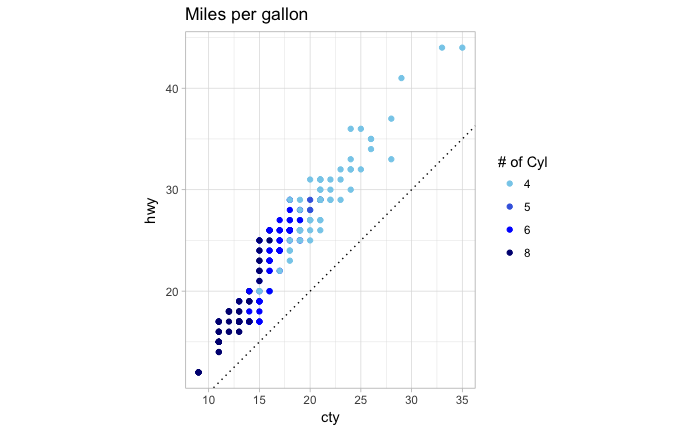

# Let’s plot!

Load the ggplot2 library:

```r
library(ggplot2)
```

`ggplot` is the base layer.

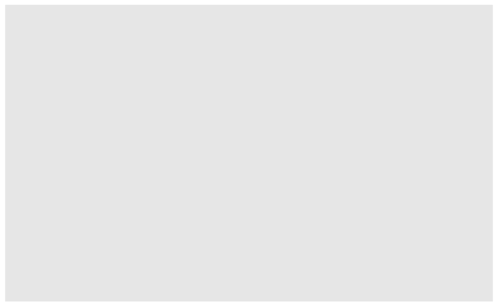

```r
ggplot()
```

This is a good place to for us to define our plot’s default data.

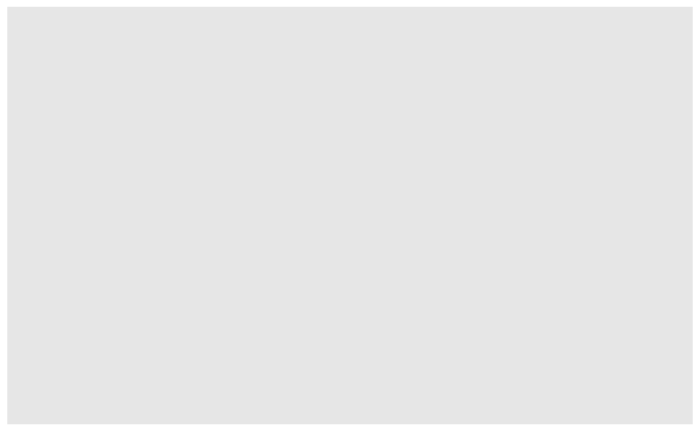

```r
ggplot(data = mpg)
```

There isn’t much being plotted yet… Let’s tell our plot about our mapping, where our `x` will be our `cty` and `y` will be our `hwy`.

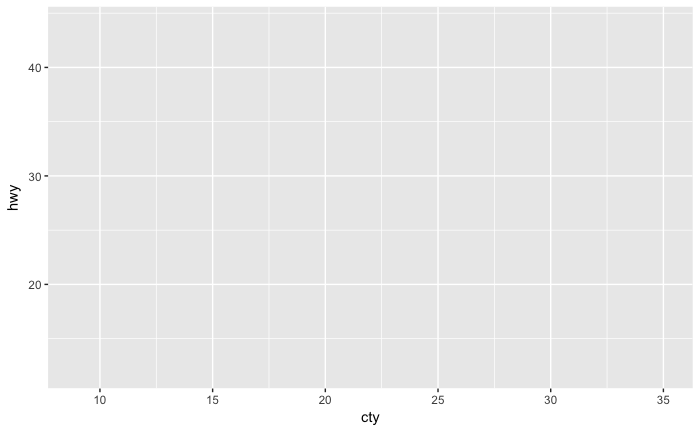

```r
ggplot(
    data = mpg,
    mapping = aes(x = cty, y = hwy)
  )
```

Our plot now has enough information to set some automatic axis limits based on the data.

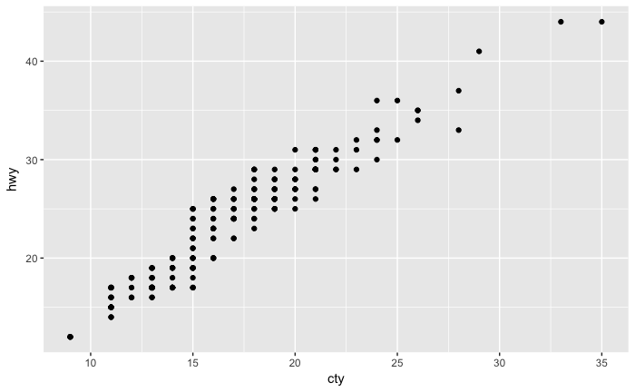

```r
ggplot(
    data = mpg,
    mapping = aes(x = cty, y = hwy)
  ) +
  geom_point()
```

We can map the number of cylinders as a set of discrete values to color.

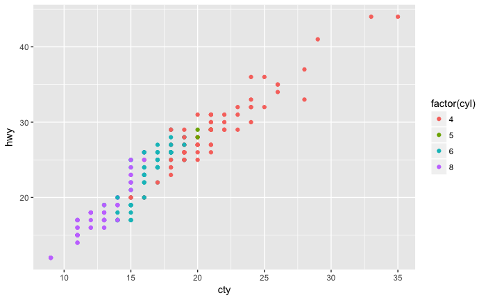

```r
ggplot(
    data = mpg,
    mapping = aes(x = cty, y = hwy)
  ) +
  geom_point(
    mapping = aes(color = factor(cyl))
  )
```

At this point, we have the base of the plot. We can save this to a variable, `mpg_base_plot`, and make additional adjustments.

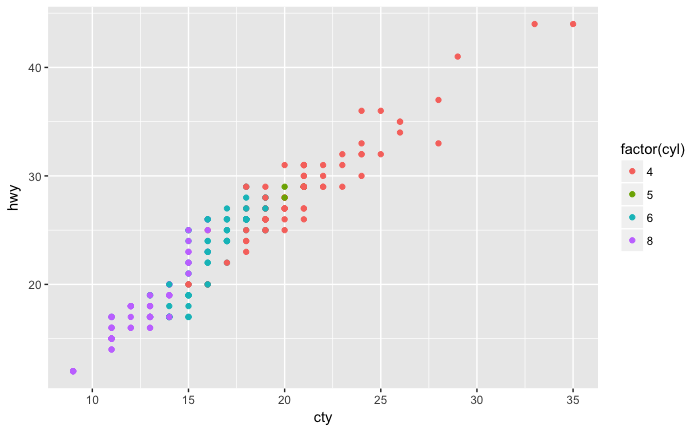

```r
mpg_base_plot <- ggplot(
    data = mpg,
    mapping = aes(x = cty, y = hwy)
  ) +
  geom_point(
    mapping = aes(color = factor(cyl))
  )
mpg_base_plot
```

To add the reference line, we add a layer like so:

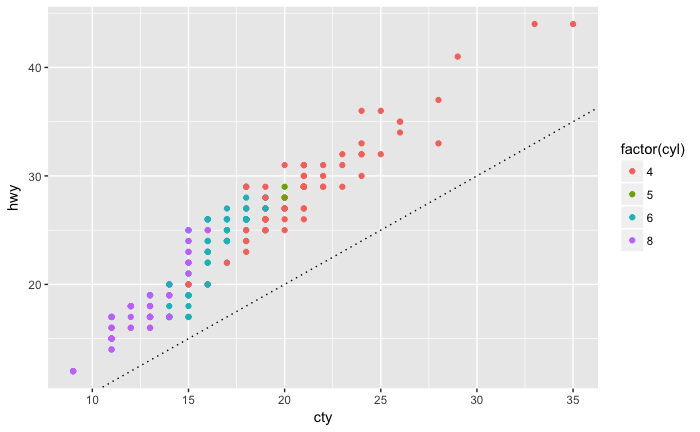

```r
mpg_base_plot +
  geom_abline(
    slope = 1,
    intercept = 0,
    color = 'black',
    linetype = 'dotted'
  )
```

Note that this geom layer can be added on top of a blank plot. All `geom_` prefixed functions return an `environment` object that holds onto the information we call it with.

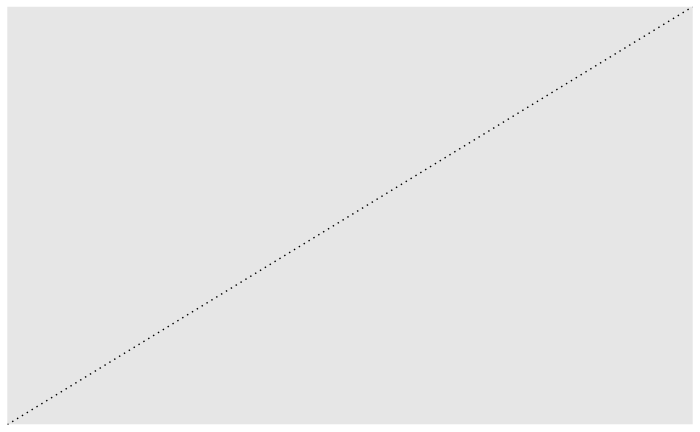

```r
ggplot() +
  geom_abline(
    slope = 1,
    intercept = 0,
    color = 'black',
    linetype = 'dotted'
  )
```

Let’s continue. Our plot looks a bit funny – the grid for the x and y are not 1 to 1. Let’s use a `coord_` function to adjust this:

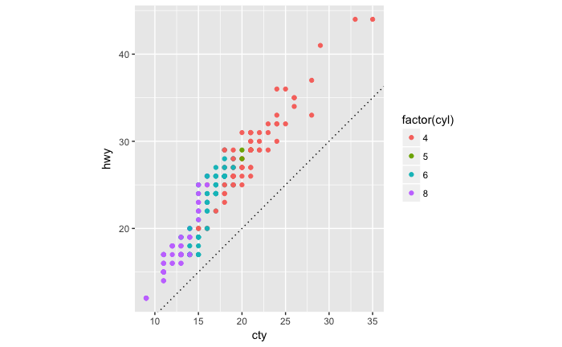

```r
mpg_base_plot +
  geom_abline(
    slope = 1,
    intercept = 0,
    color = 'black',
    linetype = 'dotted'
  ) +
  coord_fixed(ratio = 1)
```

We can clean up the plot like so:

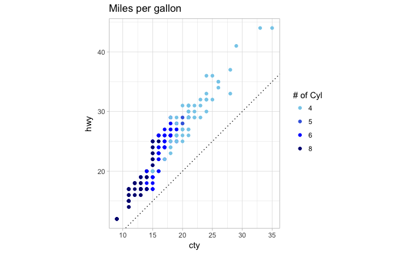

```r
mpg_plot <- mpg_base_plot +
  geom_abline(
    slope = 1,
    intercept = 0,
    color = 'black',
    linetype = 'dotted'
  ) +
  coord_fixed(ratio = 1) +
  scale_color_manual(
    name = '# of Cyl',
    values = c('skyblue','royalblue', 'blue', 'navy')
  ) +
  ggtitle('Miles per gallon') +
  theme_light()
mpg_plot
```

We can further manipulate the plot using things like `facet_`.

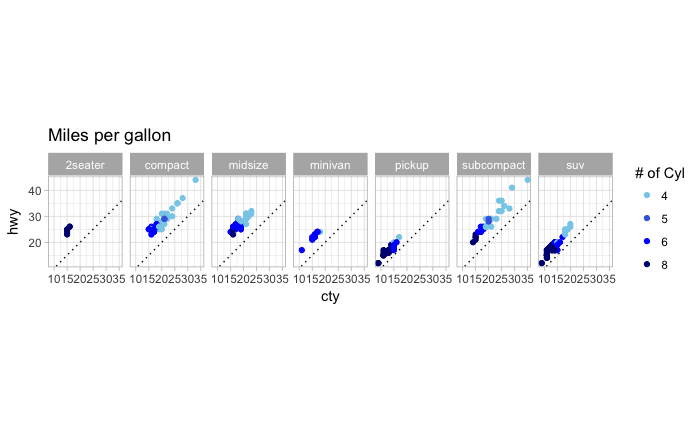

```r
mpg_plot +
  facet_grid(.~class)
```

# Let’s experiment

We can get the base plots from the ggplot cheatsheets on our computer by sourcing [this R script](https://houstonusers.github.io/intro-to-ggplot2/examples_from_cheatsheet).

```r
source('https://goo.gl/3EQSXt')
```

# The magic behind the `+`

We can discover how the `+` is helping us construct these plots by running:

```r
methods('+')
```

```
[1] +.Date   +.gg*    +.POSIXt
see '?methods' for accessing help and source code
```

From the result, we can see that the `+` function is overloaded for objects that match the `gg` namespace. If we look [at the code](https://github.com/tidyverse/ggplot2/blob/master/R/plot-construction.r#L39) for this function, we learn more about how it works.

## Object-oriented

We can explore more of how `ggplot` works underneath by looking at:

```r
base_plot <- ggplot()
names(base_plot)
```

```
[1] "data"        "layers"      "scales"      "mapping"     "theme"       "coordinates" "facet"       "plot_env"
[9] "labels"
```

It’s an object that can be mutated. Other functions output objects as well.

```r
mpg_mapping <- aes(x = cty, y = hwy)
mpg_mapping
```

```
* x -> cty
* y -> hwy
```

Let’s mutate the `base_plot`:

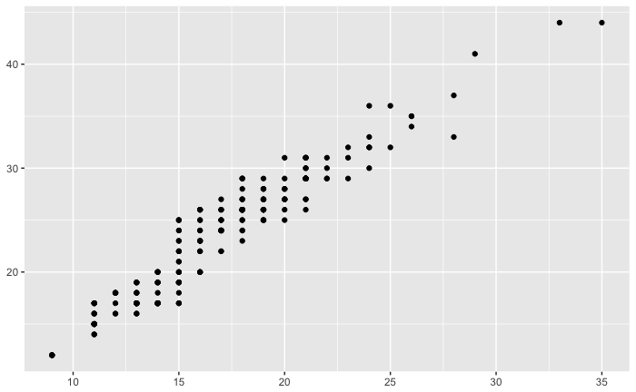

```r
base_plot$data <- mpg
base_plot$mapping <- mpg_mapping
base_plot$layers <- c(base_plot$layers, geom_point())
base_plot
```

## Extensibility

You can also create custom `stat_`s, `geom_`s, and `theme_`s as needed. This [vignette](http://docs.ggplot2.org/current/vignettes/extending-ggplot2.html) explains the object-oriented patterns for ggplot2, and how to extend the library for your needs.

There’s actually a lot we can learn from [the source code](https://github.com/tidyverse/ggplot2/tree/master/R), such as all possible [`aes` parameters](https://github.com/tidyverse/ggplot2/blob/master/R/aes.r#L4-L8).

# The makings of a pie

### Grammar-based graphics lends flexibility

Back to Leland Wilkinson’s point about making a pie – that a pie chart is really a stacked bar chart that has been transformed with polar coordinates where the y is mapped to the angle, a.k.a. theta.

### We start with a bar chart:

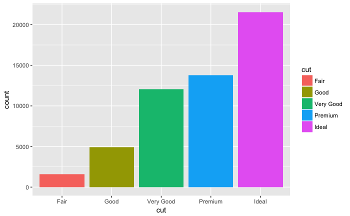

```r
diamonds_by_cut_base <- ggplot(data = diamonds, mapping = aes(x = cut, fill = cut))
diamonds_by_cut_base +
  geom_bar()
```

Here, we have a stacked bar chart of diamonds grouped by cut.

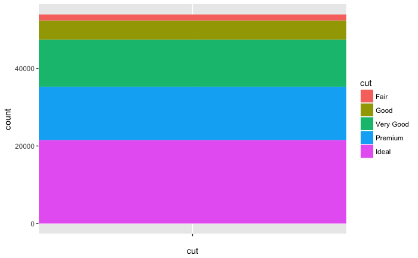

```r
diamonds_by_cut_stacked <- diamonds_by_cut_base +
  geom_bar(width = 1, aes(x=factor("")))
diamonds_by_cut_stacked
```

Taking the bar chart, we simply “add” a `coord_polar` to it.

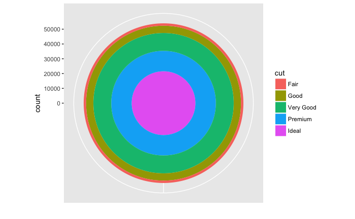

```r
diamonds_by_cut_stacked +
  coord_polar()  +
  scale_x_discrete("")
```

By default, `coord_polar` maps the `theta` from `x` and the `radius` from `y`.

```r
bullseye_coords <- coord_polar()
bullseye_coords$theta
```

```
[1] "x"
```

```r
bullseye_coords$r
```

```
[1] "y"
```

We need to a `coord_polar` where the `theta` maps from `y`:

```r
pie_coords <- coord_polar(theta = "y")
pie_coords$theta
```

```
[1] "y"
```

Now, we can transform the stacked bar chart to a pie chart:

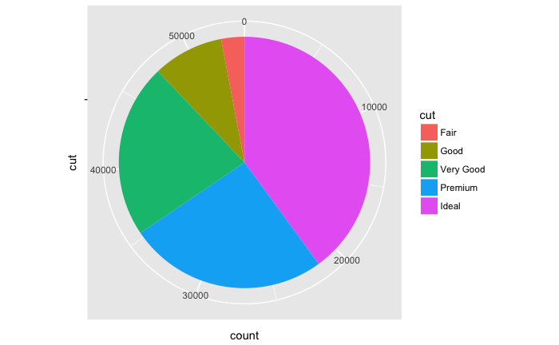

```r
diamonds_by_cut_stacked +
  pie_coords
```

```r
?coord_polar
```

# A layered grammar is powerful

The full grammar consists of:

- The base plot – `ggplot` – with default `data` and `mapping`s
- Any number of layers – `geom_` or `stat_` – each with
  - `data`
    - plot’s `data` by default
  - `mapping`
    - plot’s `mapping`s by default
    - defined by `aes`thetics
  - `geom_`
    - Sometimes defined by default by `stat_` if defined
  - `stat_`
    - Identity by default
    - Sometimes defined by default by `geom_` if defined
  - `position`
    - Optional, any adjustments necessary to geom positioning

Additionally, the grammar includes control over the whole plot’s

- `scale`s
  - to define how data values map `aes`thetic values
- `coordinate`s
- `facet`s
  - subplots

# Reading and Sources

[A Layered Grammar of Graphics](http://vita.had.co.nz/papers/layered-grammar.pdf)

[Mastering the Grammar](https://rpubs.com/flowertear/224424)

[R for Data Science: Visualizing Data](http://r4ds.had.co.nz/data-visualisation.html#introduction-1)

[Extending ggplot2](http://docs.ggplot2.org/current/vignettes/extending-ggplot2.html)

[The R Graph Gallery](http://www.r-graph-gallery.com/portfolio/ggplot2-package/)

[Data Camp: Data Visualization with ggplot2](https://www.datacamp.com/courses/data-visualization-with-ggplot2-1)

[Swirl: Exploratory Data Analysis](http://swirlstats.com/scn/eda.html)

[ggplot2 Cheatsheet](https://www.rstudio.com/wp-content/uploads/2016/11/ggplot2-cheatsheet-2.1.pdf)

[Telling stories with data using the grammar of graphics](https://codewords.recurse.com/issues/six/telling-stories-with-data-using-the-grammar-of-graphics)

[Introduction to R Graphics with ggplot2](http://tutorials.iq.harvard.edu/R/Rgraphics/Rgraphics.html)

[ggplot2 source code](https://github.com/tidyverse/ggplot2/tree/master/R)

[ggplot2: Elegant Graphics for Data Analysis](http://ggplot2.org/book/)

[The Grammar of Graphics](https://www.amazon.com/Grammar-Graphics-Statistics-Computing/dp/0387245448)

[Semiology of Graphics](https://www.amazon.com/Semiology-Graphics-Diagrams-Networks-Maps/dp/1589482611)